# DM Project

# Student’s Adaptability Level in Online Education

## The Goal of Collecting this Dataset:

The goal of our project is to build a model that can predict the adaptivity level of a student with a high degree of accuracy. We will be using classification and clustering to achieve this goal.

## Dataset Source:

The dataset was obtained from Kaggle.  
https://www.kaggle.com/datasets/mdmahmudulhasansuzan/students-adaptability-level-in-online-education

## General information:

Our dataset has 14 attributes and 1,205 objects.  
The class label is “Adaptivity Level”.

## Our attributes are as follows:

| Attribute Name | Attribute Type | Description | Possible Values |
| --- | --- | --- | --- |
| Gender | Binary | Student’s gender type | Girl, Boy |
| Age | Ordinal | Student’s age range | 1-5, 6-10, 11-15, 16-20, 21-25, 26-30 |
| Educational Level | Nominal | Student’s education institution level | School, College, University |
| Institution Type | Binary | Student’s education institution type | Government, Non-government |
| IT Student | Binary | Whether the student is studying IT or not | Yes, No |
| Location | Binary | Whether the student is studying in their hometown | Yes, No |
| Load-shedding | Binary | Level of load-shedding | High, Low |
| Financial Condition | Ordinal | Student’s family’s financial condition | Rich, Mid, Poor |
| Internet Type | Binary | Student’s most used internet type | Wifi, Mobile Data |
| Network Type | Ordinal | Network connectivity type | 2G, 3G, 4G |
| Class Duration | Ordinal | Student’s daily class duration in hours | 0, 1-3, 3-6 |
| Self LMS | Binary | Whether the student’s institution has its own LMS | Yes, No |
| Device | Nominal | Student’s most used device in class | Computer, Tab, Mobile |
| Adaptivity Level | Ordinal | Student’s adaptibility level to online education | High, Moderate, Low |

## Data Summarization and Preprocessing:

#### Installing the packages

```r
install.packages("dplyr")
```

```
Error in install.packages : Updating loaded packages
```

```r
install.packages("farver")
```

```
Error in install.packages : Updating loaded packages
```

```r
install.packages("ggplot2")
```

```
Error in install.packages : Updating loaded packages
```

```r
install.packages("colorspace")
```

```
Error in install.packages : Updating loaded packages
```

```r
install.packages("scatterplot3d")
```

```
Error in install.packages : Updating loaded packages
```

#### Reading libraries and the dataset

```r
library(ggplot2)
library(scatterplot3d)
library(dplyr)
library(readr)
dataset <- read_csv("Dataset/students_adaptability_level_online_education.csv")
```

#### Sample of raw dataset and summary

```r
View(dataset)
summary(dataset)
```

```
    Gender              Age            Education Level    Institution Type    IT Student
 Length:1205        Length:1205        Length:1205        Length:1205        Length:1205
 Class :character   Class :character   Class :character   Class :character   Class :character
 Mode  :character   Mode  :character   Mode  :character   Mode  :character   Mode  :character
   Location         Load-shedding      Financial Condition Internet Type      Network Type
 Length:1205        Length:1205        Length:1205         Length:1205        Length:1205
 Class :character   Class :character   Class :character    Class :character   Class :character
 Mode  :character   Mode  :character   Mode  :character    Mode  :character   Mode  :character
 Class Duration       Self Lms            Device          Adaptivity Level
 Length:1205        Length:1205        Length:1205        Length:1205
 Class :character   Class :character   Class :character   Class :character
 Mode  :character   Mode  :character   Mode  :character   Mode  :character
```

#### Missing values

```r
sum(is.na(dataset))
```

```
[1] 0
```

Since there are no missing values, and since there are no numerical data to be checked for outliers, we will move to the next step

#### Data summary

```r
summary(dataset$Age)
```

```
   Length     Class      Mode
     1205 character character
```

```r
summary(dataset$Gender)
```

```
   Length     Class      Mode
     1205 character character
```

```r
summary(dataset$Device)
```

```
   Length     Class      Mode
     1205 character character
```

```r
summary(dataset$Location)
```

```
   Length     Class      Mode
     1205 character character
```

```r
summary(dataset$'Self Lms')
```

```
   Length     Class      Mode
     1205 character character
```

```r
summary(dataset$'IT Student')
```

```
   Length     Class      Mode
     1205 character character
```

```r
summary(dataset$'Network Type')
```

```
   Length     Class      Mode
     1205 character character
```

```r
summary(dataset$'Internet Type')
```

```
   Length     Class      Mode
     1205 character character
```

```r
summary(dataset$'Load-shedding')
```

```
   Length     Class      Mode
     1205 character character
```

```r
summary(dataset$'Class Duration')
```

```
   Length     Class      Mode
     1205 character character
```

```r
summary(dataset$'Education Level')
```

```
   Length     Class      Mode
     1205 character character
```

```r
summary(dataset$'Adaptivity Level')
```

```
   Length     Class      Mode
     1205 character character
```

```r
summary(dataset$'Institution Type')
```

```
   Length     Class      Mode
     1205 character character
```

```r
summary(dataset$'Financial Condition')
```

```
   Length     Class      Mode
     1205 character character
```

All attribute types are char, so we can’t calculate variance or discretize.

#### Converting data types from char to factors so they can be plotted

```r
dataset$'Financial Condition' <- as.factor(dataset$'Financial Condition')
dataset$'Institution Type' <- as.factor(dataset$'Institution Type')
dataset$'Education Level' <- as.factor(dataset$'Education Level')
dataset$'Load-shedding' <- as.factor(dataset$'Load-shedding')
dataset$'Internet Type'<- as.factor(dataset$'Internet Type')
dataset$'Network Type'<- as.factor(dataset$'Network Type')
dataset$'IT Student'<- as.factor(dataset$'IT Student')
dataset$Device <- as.factor(dataset$Device)
dataset$Gender<- as.factor(dataset$Gender)
dataset$Age <- as.factor(dataset$Age)
```

### Plotting Methods:

#### Bar plot of the age attribute:

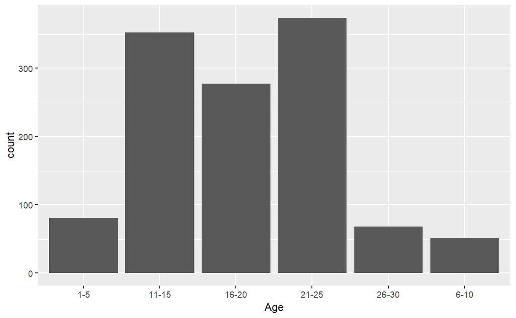

```r
ggplot(dataset, aes(x = Age)) + geom_bar()
```

Graph decsription: this graph shows us the number of students whose data been collected based on their age range, we noticed they are mostly betwen the ages of 21-25 and 11-15.

#### Mosaic plot of the educational level attribute with the financial condition

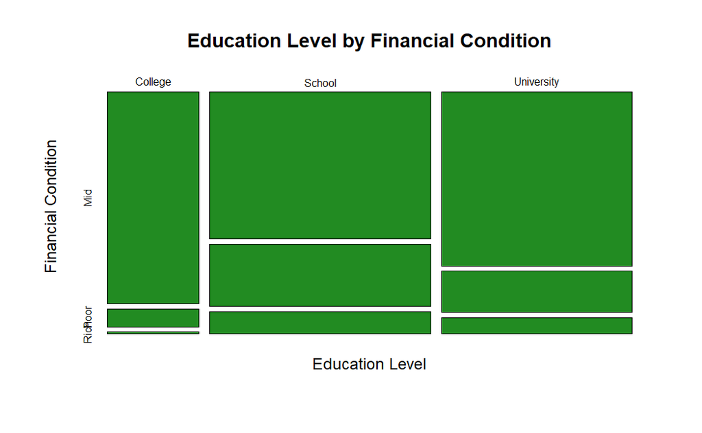

```r
counts <- table(dataset$'Education Level', dataset$'Financial Condition')
mosaicplot(counts, xlab='Education Level', ylab='Financial Condition',
           main='Education Level by Financial Condition', col='forestgreen')
```

Graph description: this graph shows us a visual comparison between students’ financial condition against there education level, we noticed that in each education level category, students mostly come from a middle-class family regarding their financial condition.

#### Scatter plots of the gender and device and class duration attributes and internet type and load-shedding and institution type attributes

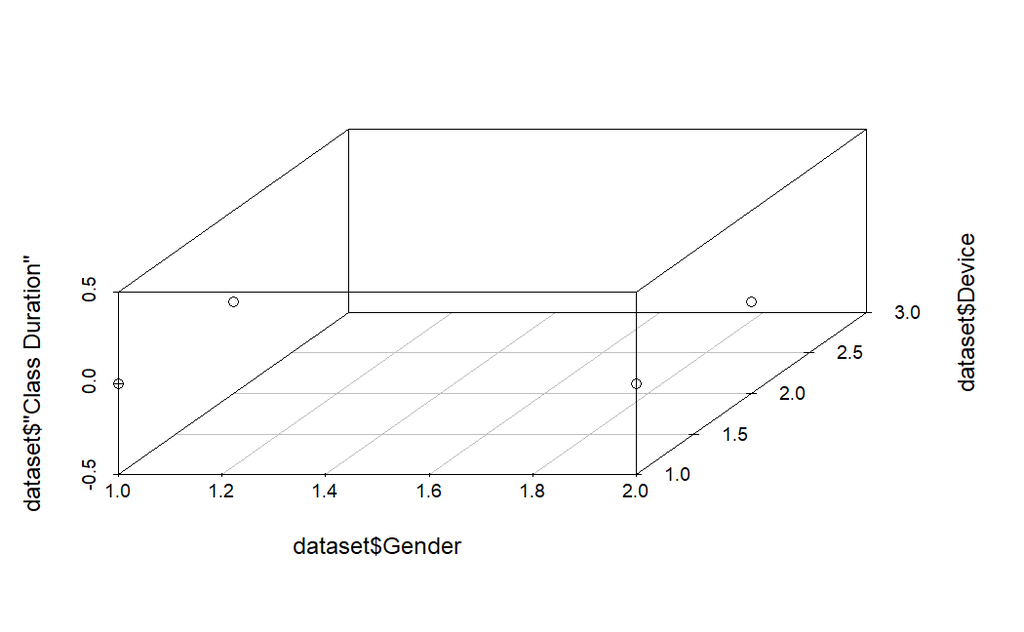

```r
scatterplot3d(dataset$Gender,dataset$Device, dataset$'Class Duration')
```

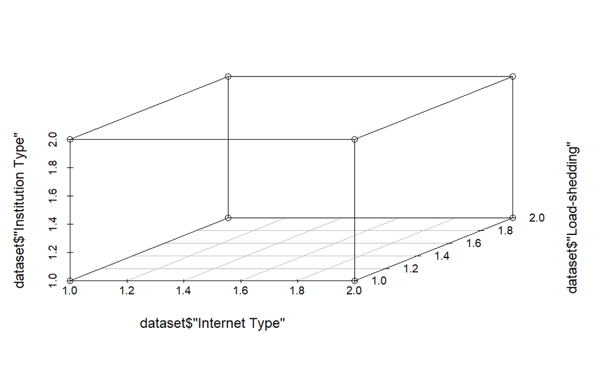

```r
scatterplot3d(dataset$'Internet Type',dataset$'Load-shedding', dataset$'Institution Type')
```

Graph description - scatter plot 1: scatter plot showing the relation between the gender, most used device, and hours of attended class per day

Graph description - scatter plot 2: scatter plot showing the relation between the institution type, most used internet type by students, and level of load-shedding.

#### Pie chart for the self-LMS attribute

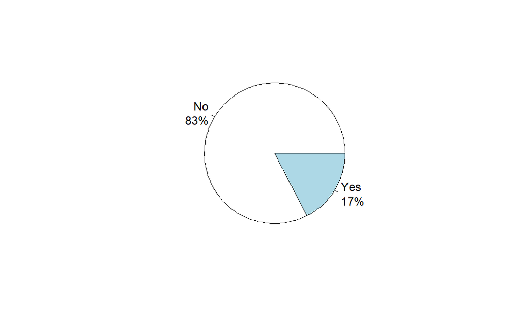

```r
tab <- dataset$'Self Lms'%>% table()
precentages <- tab %>% prop.table() %>% round(2) * 100
txt <- paste0(names(tab), '\n', precentages, '%')
pie(tab, labels=txt)
```

Graph description: a pie chart of the self-LMS attribute that shows us the percentage of institutions that has their own LMS, we notice that most of them, by a 83% percentage, do not have their own.

#### Pie chart for the IT student attribute:

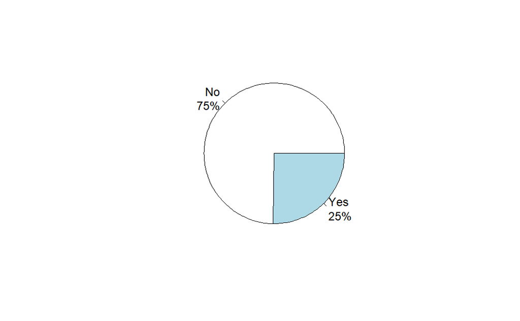

```r
tab <- dataset$'IT Student'%>% table()
precentages <- tab %>% prop.table() %>% round(2) * 100
txt <- paste0(names(tab), '\n', precentages, '%')
pie(tab, labels=txt)
```

Graph description: a pie chart of the IT student attribute that shows us the percentage of students who are studying IT, we notice that most of them, by a 75% percentage, are not.

#### Pie chart for the adaptivity level attribute

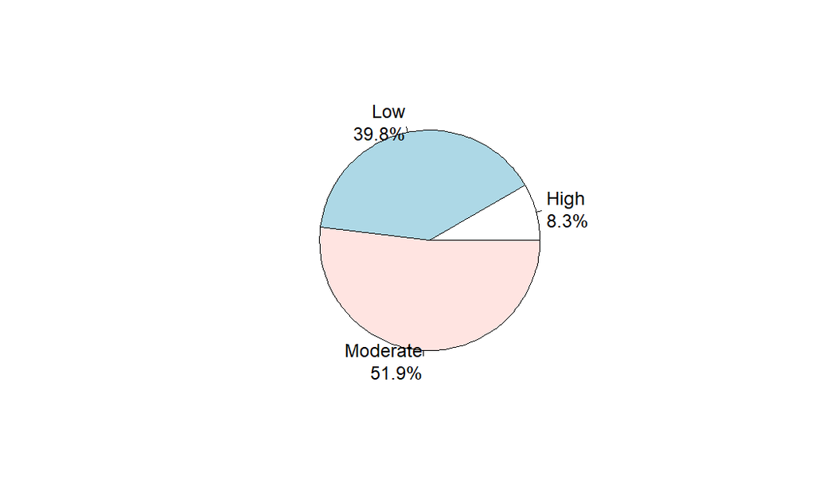

```r
tab <- dataset$'Adaptivity Level'%>% table()
precentages <- tab %>% prop.table() %>% round(3) * 100
txt <- paste0(names(tab), '\n', precentages, '%')
pie(tab, labels=txt)
```

Graph description: a pie chart of the adaptivity level attribute that shows us the percentages of students adaptivity level in online education, which is our class label, we notice that most of them, by a 51.9% percentage, have a moderate adaptivity level, 39.8% have a low adaptivity level, and only 8.3% have a high adaptivit level.

Since this dataset only contains categorical data, discreization and normalization cannot be performed.

#### Encoding categorical variables

```r
datasetEncoded<-dataset
datasetEncoded$Gender= factor(datasetEncoded$Gender, c("Boy","Girl"),c(0,1))
datasetEncoded$Location= factor(datasetEncoded$Location, c("No","Yes"),c(0,1))
datasetEncoded$'Self Lms'= factor(datasetEncoded$'Self Lms', c("No","Yes"),c(0,1))
datasetEncoded$'IT Student'= factor(datasetEncoded$'IT Student', c("No","Yes"),c(0,1))
datasetEncoded$Device= factor(datasetEncoded$Device, c("Mobile","Computer","Tab"),c(0,1,2))
datasetEncoded$'Load-shedding'= factor(datasetEncoded$'Load-shedding', c("Low","High"),c(0,1))
datasetEncoded$'Network Type'= factor(datasetEncoded$'Network Type', c("2G","3G","4G"),c(0,1,2))
datasetEncoded$'Class Duration'= factor(datasetEncoded$'Class Duration', c("0","1-3","3-6"),c(0,1,2))
datasetEncoded$'Internet Type'= factor(datasetEncoded$'Internet Type', c("Wifi","Mobile Data"),c(0,1))
datasetEncoded$Age= factor(datasetEncoded$Age, c("1-5","6-10","11-15","16-20","21-25","26-30"),c(0,1,2,3,4,5))
datasetEncoded$'Adaptivity Level'= factor(datasetEncoded$'Adaptivity Level', c("Low","Moderate","High"),c(0,1,2))
datasetEncoded$'Financial Condition'= factor(datasetEncoded$'Financial Condition', c("Poor","Mid","Rich"),c(0,1,2))
datasetEncoded$'Institution Type'= factor(datasetEncoded$'Institution Type', c("Non Government","Government"),c(0,1))
datasetEncoded$'Education Level'= factor(datasetEncoded$'Education Level', c("School","College","University"),c(0,1,2))
```

#### Sample of encoded dataset and summary

```r
View(datasetEncoded)
summary(datasetEncoded)
```

```
 Gender  Age     Education Level Institution Type IT Student Location Load-shedding Financial Condition
 0:663   0: 81   0:530           0:823            0:901      0:270    0:1004        0:242
 1:542   1: 51   1:219           1:382            1:304      1:935    1: 201        1:878
         2:353   2:456                                                              2: 85
         3:278
         4:374
         5: 68
 Internet Type Network Type Class Duration Self Lms Device   Adaptivity Level
 0:510         0: 19        0:154          0:995    0:1013   0:480
 1:695         1:411        1:840          1:210    1: 162   1:625
               2:775        2:211                   2:  30   2:100
```

#### Chi Square

```r
chisq.test(datasetEncoded$'Institution Type', datasetEncoded$'Financial Condition')
```

```
    Pearson's Chi-squared test

data:  datasetEncoded$"Institution Type" and datasetEncoded$"Financial Condition"
X-squared = 6.0127, df = 2, p-value = 0.04947
```

since the p value is not above 0.05 and therefore, the institution type depends on the financial condition.

## Data Mining: